# Assignment 4 - Digitizing and Open data

Author

COMFORT ADEGBENRO

# 1 Instructions

Once you download this script from GitHub, then:

- Move it into your already-created project folder structure “06_opendata”, inside the “code” sub-folder.
- You do not need to create new scripts. You can use the class scripts to copy code from, and paste those chunks in this script. All the code needed for this assignment should be inserted in this script.
- I left you the scaffolding of the structure of the exercise (i.e., look on the outline to the right). However, it is your job to decide which chunks/codes you need to paste in this script to answer the questions.
- Make sure that when you paste chunks/codes from the class scripts, that you place the chunks/codes under the appropriate section (again, look on the outline to the right). For ex., the chunk containing the packages needed for the exercise should be under the “Setup” heading 1.
- Besides code, there are 3 specific questions in this script. Make sure that you produce the plot/table needed to answer them, AND that you also write down a sentence for your answer. Only showing a plot/table is not sufficient in answering the questions.

# 2 Introduction

Now it is your turn to

- digitize a field boundary
- retrieve open data related to soil series and elevation, and
- create plots to explore it

Find an agricultural field of your interest. This could be a field from a farm you have access to, or perhaps a field on a UGA research station where your studies were/are/will be conducted.

## 2.1 Question 1) Provide below the longitude and latitude of the centroid of your selected field.

- longitude: -84.2968798
- latitude: 31.2831540

This field is located at the Camilla Stripling Irrigation Station, in Camilla Georgia.

# 3 Setup

Use this section to load the necessary packages. Remember, you will to do digitizing AND open data retrieval in this same script.

```r
library(tidyverse) #dplyr, tidyr, ggplot2
library(sf) # geospatial vector objects
library(mapview) # interactive maps
library(elevatr) # open-source elevation data
library(stars) # geospatial raster objects
library(FedData) # open-source soil series data
library(ggspatial) # for map components
library(ggthemes) # for theme_map()
library(patchwork) # combine multiple plots
library(leaflet.extras) # for digitizing drawing tool bar
library(mapedit) # for creating the boundary
library(magick)
```

# 4 Digitizing

Use this section to digitize AND export to file (as .geojson) the boundary of your selected field. When exporting the boundary, make sure to export it to the `output` folder.

```r
# A bit of wrangling
centroid = data.frame(lon = -84.2968798,
                      lat = 31.2831540) %>%
  # Transforming df into sf
  st_as_sf(coords = c("lon", "lat")) %>%

  # Assigning proper CRS
  st_set_crs(value = 4326)

# view the object and create map for digitizing
digitizing = mapview(centroid,
                     map.types = "Esri.WorldImagery")@map %>%
  addDrawToolbar()
digitizing
```

[interactive chart not shown]

```r
# digitize the boundary and save as boundary
#boundary = editMap(digitizing)
#boundary

# extract the finished component
#boundary_w  = boundary$finished
#boundary_w

#mapview(boundary_w)

#write_sf(boundary_w,
        # "../ouput/boundary-n.geojson",
        # delete_dsn = T)
```

**NOTE**: right before you render this script for submission, comment off the digitizing code so it does not run when rendering. You will need to write a code to import your previously-created boundary at the time of rendering (I’ll demo this).

```r
sf::sf_use_s2(FALSE) # had an error so ran this line of code to turn off the S2 Geometry Engine.

boundary_n = read_sf("../../06_opendata/ouput/boundary-n.geojson")

mapview(boundary_n,
        map.types = "Esri.WorldImagery")
```

[interactive chart not shown]

# 5 Soil series

Use this section to:

- retrieve SSURGO data for your field,
- perform the required wrangling steps, and
- create maps for soil series name and corn yield

```r
soils_n = get_ssurgo(boundary_n,
                   label = "ssurgo2",
                   raw.dir = "../data/ssurgo2/raw/",
                   extraction.dir = "../data/ssurgo2/extract")
```

## 5.1 Question 2) How many different soil series were found in this field? What is their names?

```r
soils_n$tabular$muaggatt %>%
  select(musym, muname)
```

```
# A tibble: 1 × 2
  musym muname
  <chr> <chr>
1 LmB   Lucy loamy sand, 0 to 5 percent slopes
```

There is only one soil series for this field and it is called the Lucy loamy sand, with 0 to 5 percent slopes.

```r
series_sf <-
  # Starting with the spatial component, currently an sp object
  soils_n$spatial %>%

    # Cleaning names
  janitor::clean_names() %>%

    # Joining with the muaggatt tabular data using a common column (musym)
  left_join(soils_n$tabular$muaggatt, by = "musym") %>%

    # Cropping to the boundary
  st_intersection(boundary_n)

series_sf
```

```
Simple feature collection with 1 feature and 45 fields
Geometry type: POLYGON
Dimension:     XY
Bounding box:  xmin: -84.29982 ymin: 31.28164 xmax: -84.29478 ymax: 31.28516
Geodetic CRS:  WGS 84
# A tibble: 1 × 46
  areasymbol spatialver musym mukey.x muname  mustatus slopegraddcp slopegradwta
* <chr>           <dbl> <chr> <chr>   <chr>   <lgl>           <dbl>        <dbl>
1 GA603               7 LmB   325159  Lucy l… NA                  3            3
# ℹ 38 more variables: brockdepmin <lgl>, wtdepannmin <dbl>,
#   wtdepaprjunmin <dbl>, flodfreqdcd <chr>, flodfreqmax <chr>,
#   pondfreqprs <dbl>, aws025wta <dbl>, aws050wta <dbl>, aws0100wta <dbl>,
#   aws0150wta <dbl>, drclassdcd <chr>, drclasswettest <chr>, hydgrpdcd <chr>,
#   iccdcd <dbl>, iccdcdpct <dbl>, niccdcd <dbl>, niccdcdpct <dbl>,
#   engdwobdcd <chr>, engdwbdcd <chr>, engdwbll <chr>, engdwbml <chr>,
#   engstafdcd <chr>, engstafll <chr>, engstafml <chr>, engsldcd <chr>, …
```

```r
mapview(series_sf,
        zcol = "muname",
        map.types = "Esri.WorldImagery")
```

[interactive chart not shown]

This shows an interactive map of the soil series. This field is a uniform one with no variability in the soil series.

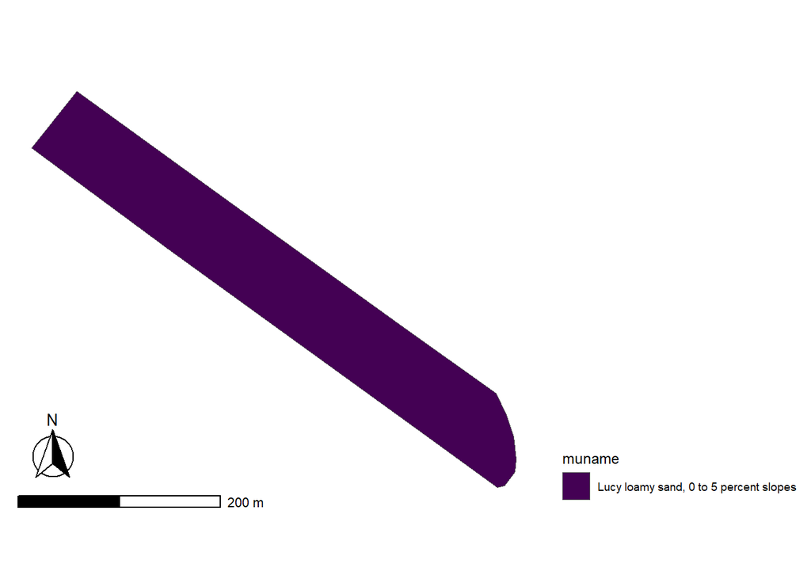

```r
series_map = ggplot() +
  geom_sf(data = boundary_n, alpha = 0.5) +
  geom_sf(data = series_sf,
          aes(fill = muname)) +
  scale_fill_viridis_d() +
  theme_map() +
  theme(legend.position = "right") +
  annotation_scale(location = "bl",
                   width_hint = 0.4,
                   pad_y = unit(-0.0001, "in")) +
  annotation_north_arrow(pad_y = unit(0.2, "in"),
                         style = north_arrow_fancy_orienteering())

series_map
```

Since we have only one soil series, the color scale for the soil series static map shows only one color, depicting uniformity across the field. This means the field is dominated by only one soil type (Lucy loamy sand, 0-5% slopes).

## 5.2 Question 3) Was there yield data available for any crop for the soil series within your field? List below which crops had yield data available.

```r
soils_n$tabular$mucropyld %>%
  head()
```

```
# A tibble: 6 × 10
  cropname         yldunits nonirryield.l nonirryield.r nonirryield.h irryield.l
  <chr>            <chr>            <dbl>         <dbl>         <dbl>      <dbl>
1 Warm season gra… AUM                  4           4.5             5         NA
2 Wheat            Bu                  35          37.5            40         NA
3 Peanuts          Lbs               2500        2750            3000         NA
4 Corn             Bu                  65          75              80         NA
5 Cotton lint      Lbs                500         550             650         NA
6 Grain sorghum    Bu                  35          65              85         NA
# ℹ 4 more variables: irryield.r <dbl>, irryield.h <dbl>, mukey <dbl>,
#   mucrpyldkey <dbl>
```

Crops with yield values are: warm season grasses, wheat, peanuts, corn, cotton, grain sorghum, alfalfa, bahiagrass hay, grass hay, bahiagrass, cool season grasses, improved bermudagrass and soybeans. All crops have yield data for non-irrigated but not irrigated yields.

## 5.3 Question 4) IF your field had data for crop yield, choose one crop only. List below what was the crop you selected, and what were the different values of yield for the selected crop for these different soil series (if your field had no crop yield data, than explain so).

Choosing the crop, Soybeans to create the yield sf object, and subsequently yield map.

```r
yield_sf <-
  # Starting with the spatial component, currently an sp object
  soils_n$spatial %>%
  # Transforming from sp to sf
  st_as_sf() %>%
  # Cleaning names
  janitor::clean_names() %>%
  mutate(mukey = as.numeric(mukey)) %>%
  # Joining with the muaggatt tabular data using a common column (musym)
  left_join(soils_n$tabular$mucropyld, by = "mukey") %>%
  # Cropping to the boundary
  st_intersection(boundary_n) %>%
  # Selecting only needed columns
  select(mukey, cropname, yldunits, nonirryield.r, geom) %>%

    # Only keeping Soybeans
  filter(cropname=="Soybeans")

yield_sf
```

```
Simple feature collection with 1 feature and 4 fields
Geometry type: POLYGON
Dimension:     XY
Bounding box:  xmin: -84.29982 ymin: 31.28164 xmax: -84.29478 ymax: 31.28516
Geodetic CRS:  WGS 84
# A tibble: 1 × 5
   mukey cropname yldunits nonirryield.r                                    geom
*  <dbl> <chr>    <chr>            <dbl>                           <POLYGON [°]>
1 325159 Soybeans Lbs                 32 ((-84.29935 31.28516, -84.29775 31.284…
```

The table above presents only one yield value (32 lb) for soybeans.

```r
mapview(yield_sf,
        zcol = "nonirryield.r",
        map.types = "Esri.WorldImagery")
```

[interactive chart not shown]

Due to having one soil series, the yield is also presented as constant across the field with no variation.

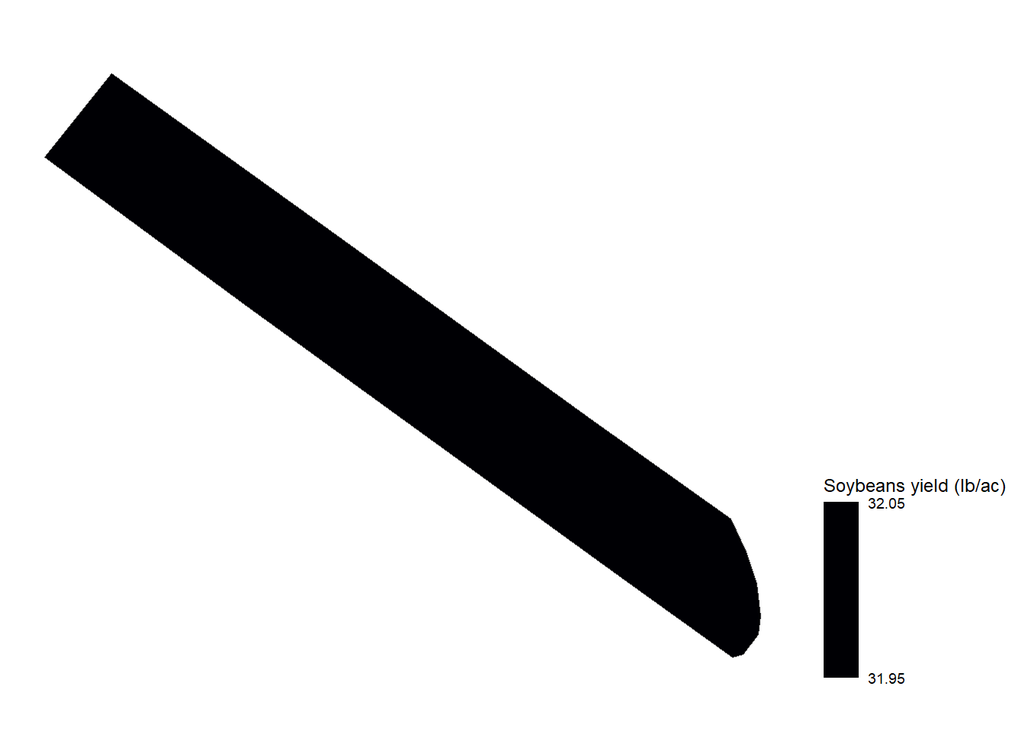

```r
yield_map <- ggplot() +
  geom_sf(data = series_sf) +
  geom_sf(data = yield_sf, aes(fill = nonirryield.r)) +
  scale_fill_viridis_b(option = "A") +
  labs(fill = "Soybeans yield (lb/ac)") +
  theme_map() +
  theme(legend.position = "right")

yield_map
```

# 6 Elevation

Use this section to:

- retrieve elevation data at the highest zoom level possible
- perform the required wrangling steps, and
- create a map for elevation

```r
elevation = get_elev_raster(boundary_n,
                            z = 14) %>%
  st_as_stars() %>%
  st_crop(boundary_n)

elevation
```

```
stars object with 2 dimensions and 1 attribute
attribute(s):
                     Min.  1st Qu.   Median     Mean  3rd Qu.     Max. NA's
file435093c1319  49.93627 50.16405 50.53115 50.58662 50.92936 51.68957 8363
dimension(s):
  from  to offset     delta refsys point x/y
x  760 883 -84.33  4.11e-05 WGS 84  TRUE [x]
y  297 382   31.3 -4.11e-05 WGS 84  TRUE [y]
```

From the summary above, the elevation of this field ranged from 49.94 to 51.69 m, with a mean and median of 50.59 m and 50.53 m, respectively, indicating a very low-relief and relatively uniform landscape. This shows minimal topographic variation.

```r
mapview(elevation)
```

[interactive chart not shown]

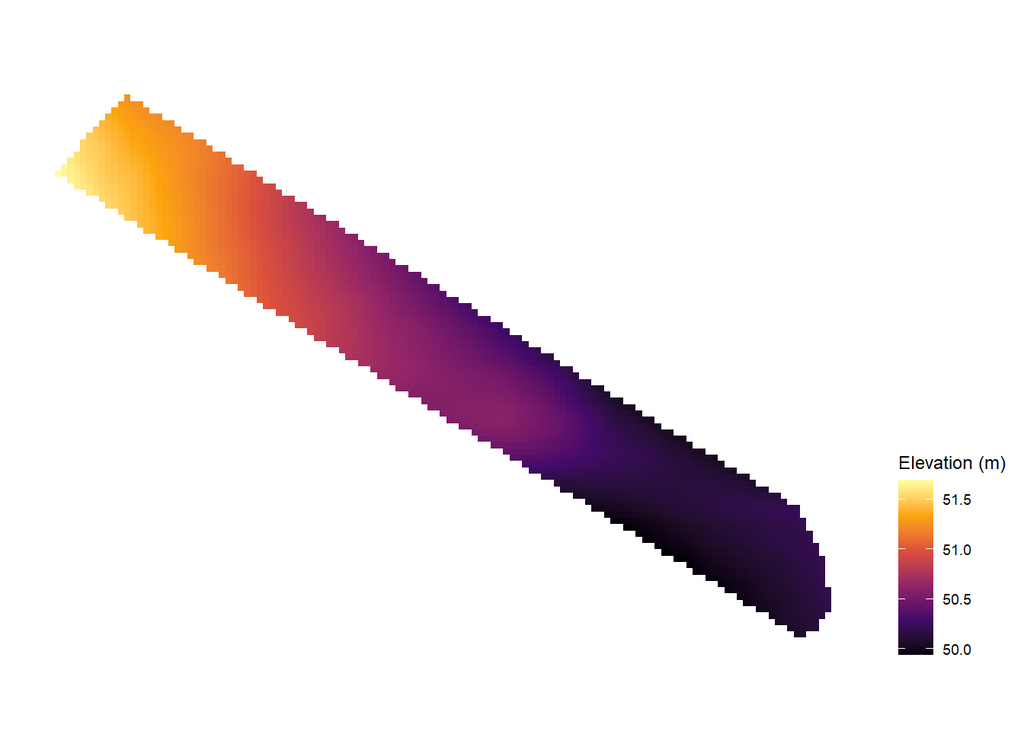

```r
elevation_map = ggplot() +
  geom_stars(data = elevation) +
  coord_equal() +
  scale_fill_viridis_c(option = "B", na.value = "white") +
  theme_map() +
  labs(fill = "Elevation (m)") +
  theme(legend.position = "right")

elevation_map
```

This pattern reveals a consistent slope across the field, rather than isolated depressions or mounds. The smooth color transition suggests minimal abrupt topographic changes and confirms that the landscape has low overall relief, and the total elevation difference is small (~1.75 m).

# 7 Combining and exporting maps

Use this section to combine your individual static maps above into one, and export it to file.

[figure not shown]

```r
#series_map + yield_map + elevation_map +
  #plot_annotation(title = "Soil series (a), Cotton yield (b), and elevation (c)",
                  #tag_levels = "a",
                  #tag_suffix = ")"
                 # ) &
  #theme(plot.title = element_text(size = 20,
                                  #hjust = 0.5))
#ggsave("../ouput/combined_maps_ass.png",
       #width = 12,
       #height = 6)

combined_maps = image_read("../ouput/combined_maps_ass.png")
print(combined_maps, info = FALSE)
```

## 7.1 Question 5) Now that you can visualize all three maps together, try to explain the effect of soil series and elevation on crop yield. Which soil and elevation conditions seem to promote higher yields in this field?

The soil map shows that the entire field had a single soil series (Lucy loamy sand), so there is no soil variability to drive spatial differences in yield. Although elevation varies a bit across the field, the total relief is only about 1.75 m and forms a smooth, uniform slope. This small change in elevation was probably insufficient to create meaningful differences in water redistribution and overall yield. As a result, the yield map shows almost no spatial variability and does not correspond to either soil or elevation. This indicates that the field performed uniformly across all areas.

# 8 Submitting your work

Once you have developed all the code and answers, make sure to Render this quarto file.

**Notes on rendering**:

- Make sure to render your work and inspect how the final html look like.
- If it does not look professional for whatever reason, then fix the issue, re-render it, recheck.
- Only send me your work once your html file looks professional.
  - **DO NOT** delete the file’s heading levels (# and ##). They set up the proper heading 1 and 2 levels, and I use them to guide my grading.
  - If a given chunk is also outputting warnings or messages, inhibit this behavior by changing the chunk options `message` and `warning` to `FALSE` (I’ll demo this in a moment).
  - If, after rendered, 2 lines of text are connected and you wish to “break line” between them, add 2 extra spaces after the first one (I’ll demo this in a moment).

After rendering, an .html file will be created on your `code` folder.

Rename this file to `assignment-04-opendata-LASTNAME.html`.

For ex., mine would be `assignment-04-opendata-Bastos.html`.

Upload the **html** file to eLC by Wednesday Feb 18th 11:59 pm.